# Midterm HW

통계 1714615 김승주

##3.

```r
library(quantreg)
```

### (b)

#### 0.1분위수가 2+3x를 만족하는 데이터셋을 다음과 같이 생성하였다.

```r
set.seed(1)
n =1000
X2 = rnorm(n)

beta.true = c(2,3)
x_beta = beta.true[1] + beta.true[2] * X2

Y2 = rnorm(n=n, mean=x_beta+1.3)
```

**원래 선형회귀에서 오차의 정규성과 독립성, 그리고 등분산성이 만족되었을때 Y가 정규분포를 따르고 이러한 오리지널 선형회귀를 떠올려 보았을때 추정된 회귀식은 각 x값에 대한 반응변수 y의 기대값을 구하는 모형이다. 이는 quantile(0.5) 즉 특정 x에 대한 y의 mean값을 추정하는 것과 같다. 또한 각 x 값에서의 quantile을 대표하는 y들을 따라 선을 그었을때 그 기울기가 3으로 모두 동등할 것이다. (오차의 가정때문) 따라서 원 데이터가 2+3x를 따르는 Y의 분포에 일정 상수만큼 Y축 평행이동 시켜주어 특정 x값에 대한 하위 10% y들을 이었을때 2+3x를 따르는 데이터를 생성하였다.**

```r
result1_2 = rq(Y2~X2, tau=0.5)
result2 = rq(Y2~X2, tau=0.1)
summary(result1_2)
```

```
##
## Call: rq(formula = Y2 ~ X2, tau = 0.5)
##
## tau: [1] 0.5
##
## Coefficients:
##             coefficients lower bd upper bd
## (Intercept) 3.27021      3.20732  3.33050
## X2          3.00721      2.89925  3.08956
```

```r
summary(result2)
```

```
##
## Call: rq(formula = Y2 ~ X2, tau = 0.1)
##
## tau: [1] 0.1
##
## Coefficients:
##             coefficients lower bd upper bd
## (Intercept) 1.95651      1.84484  2.02641
## X2          3.00640      2.94835  3.06253
```

#### 표본크기(n)을 키워보자. 그리고 각 오류측도들을 계산해 비교해보자.

```r
set.seed(1)
n =5000
X3 = rnorm(n)

beta.true = c(2,3)
x_beta = beta.true[1] + beta.true[2] *X3

Y3 = rnorm(n=n, mean=x_beta+1.3)

result3 = rq(Y3~X3, tau=0.1)
result1_3 = rq(Y3~X3, tau=0.5)
summary(result3)
```

```
##
## Call: rq(formula = Y3 ~ X3, tau = 0.1)
##
## tau: [1] 0.1
##
## Coefficients:
##             Value     Std. Error t value   Pr(>|t|)
## (Intercept)   2.00654   0.02512   79.88361   0.00000
## X3            3.01832   0.02402  125.64398   0.00000
```

```r
set.seed(1)
n =10000
X = rnorm(n)

beta.true = c(2,3)
x_beta = beta.true[1] + beta.true[2] *X

Y = rnorm(n=n, mean=x_beta+1.3)

result = rq(Y~X, tau=0.1)
result1 = rq(Y~X, tau=0.5)
summary(result)
```

```
##
## Call: rq(formula = Y ~ X, tau = 0.1)
##
## tau: [1] 0.1
##
## Coefficients:
##             Value     Std. Error t value   Pr(>|t|)
## (Intercept)   2.04438   0.01597  128.05041   0.00000
## X             2.98991   0.01573  190.13134   0.00000
```

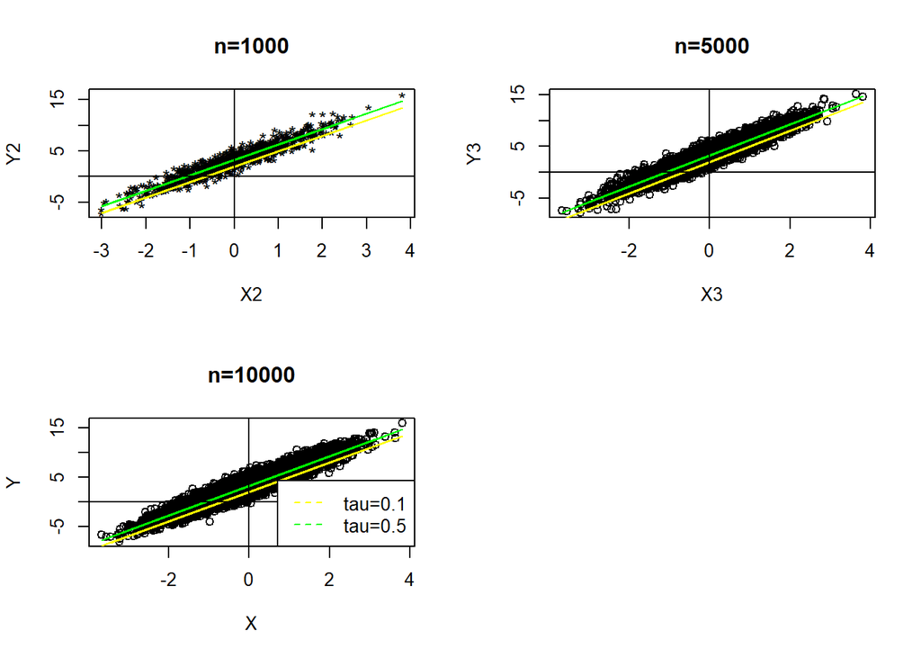

```r
par(mfrow=c(2,2))
plot(X2,Y2,pch="*", main = "n=1000")
lines(X2,result2$fitted.values, col="yellow")
lines(X2,result1_2$fitted.values, col="green")
abline(h=0,v=0)

plot(X3,Y3,main = "n=5000")
lines(X3,result3$fitted.values, col="yellow")
lines(X3,result1_3$fitted.values, col="green")
abline(h=0,v=0)

plot(X,Y,main = "n=10000")
lines(X,result$fitted.values, col="yellow")
lines(X,result1$fitted.values, col="green")
abline(h=0,v=0)

legend("bottomright", c( "tau=0.1", "tau=0.5") , col=c("yellow","green"), lty=2)
```

```r
sqrt(mean((Y2-result2$fitted.values)^2)) # N=1000
```

```
## [1] 1.685874
```

```r
sqrt(mean((Y3-result3$fitted.values)^2)) # N=5000
```

```
## [1] 1.62596
```

```r
sqrt(mean((Y-result$fitted.values)^2)) # N=10000 ... n이 큰 값일수록 오류측도인 RMSE가 작아짐
```

```
## [1] 1.596142
```

### (c)

```r
# 데이터 불러오기
load("Cheongpa2.Rdata")
head(Cheongpa2)
```

```
##         Date Today  Lag1  Lag2  Lag3  Lag4  Lag5  Lag6  Lag7
## 1 2018-12-08 19785 26437 27519 27105 26583 26618 22751 24606
## 2 2018-12-09 20630 19785 26437 27519 27105 26583 26618 22751
## 3 2018-12-10 26257 20630 19785 26437 27519 27105 26583 26618
## 4 2018-12-11 25284 26257 20630 19785 26437 27519 27105 26583
## 5 2018-12-12 25862 25284 26257 20630 19785 26437 27519 27105
## 6 2018-12-13 25054 25862 25284 26257 20630 19785 26437 27519
```

```r
# 데이터셋 나누기 (tr : val : te = 6:2:2)
tr = 0.6
va = 0.2
n = nrow(Cheongpa2)

train = Cheongpa2[1 : floor(n*tr),]
val = Cheongpa2[(floor(n*tr) + 1 ) : floor(n*(tr + va)), ]
test = Cheongpa2[(floor(n*(tr + va)) + 1 ): n, ]
```

- Train Data에서의 linear quantile regression과 시각화 #### 이때 깔끔한 그래프를 위해 tau가 0.1일때와 0.5일때만을 시각화 하였다. #### 나머지 모든 tau에 대해 그래프를 그리고자하는 코드는 주석으로 남겨두었다.

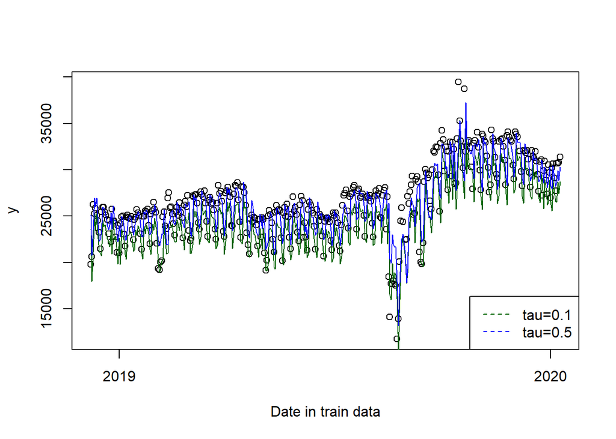

```r
tau = c(0.1,0.3,0.5,0.7,0.9)
#total.result = as.list(rep(NA,time=length(tau)))
#names(total.result) = tau
#for ( t in 1:length(tau)) {
#  total.result[[t]] = rq(y.train ~ x.train, tau=tau[t])
#}
#total.result

fit.rq =  rq(Today~., data=train[,-1], tau=tau)
plot(train[,1], train[,2], xlab="Date in train data", ylab = "y" )
# to see all the fitted valuew in each tau
#for ( i in 1:length(tau)) {
#  lines(x=train[,1], y=rq(Today~., data=train[,-1], tau=tau[i])$fitted.values, col=i)
#}
lines(train[,1], rq(Today~., data=train[,-1], tau=tau[1])$fitted.values, col = "darkgreen")
lines(train[,1], rq(Today~., data=train[,-1], tau=tau[3])$fitted.values, col='blue')
legend("bottomright", c( "tau=0.1", "tau=0.5") , col=c("darkgreen","blue"), lty=2)
```

* 검증세트 적합

```r
pred.rq = predict(fit.rq, newdata=val[,-1])
```

- 시각화

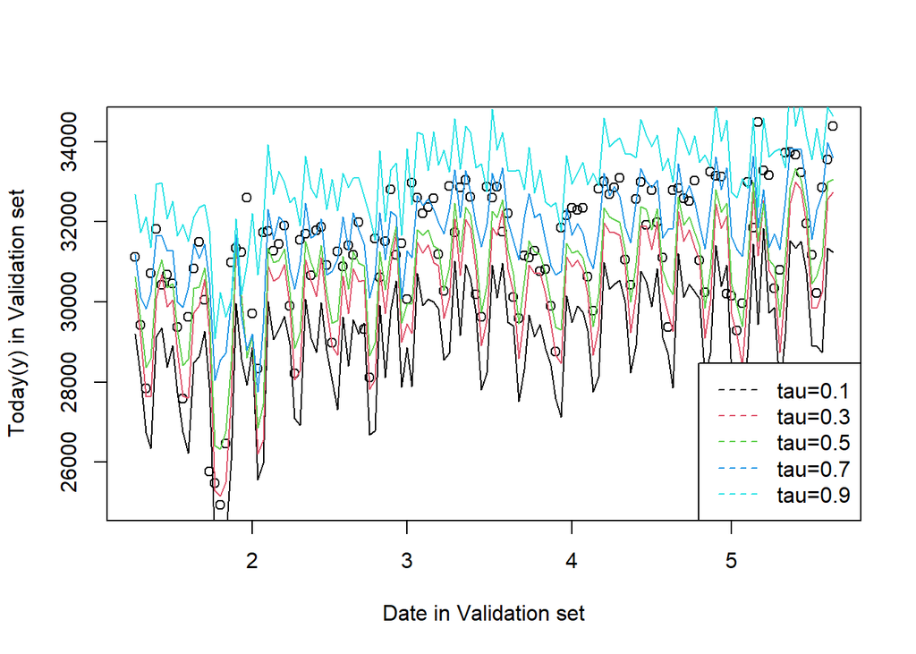

```r
plot(val[,1], val[,2], xlab = "Date in Validation set", ylab = "Today(y) in Validation set")
for (i in 1:length(tau)) {
  lines(val$Date, pred.rq[,i] , col=i)
}
legend("bottomright", c( "tau=0.1", "tau=0.3", "tau=0.5", "tau=0.7" , "tau=0.9") , col=1:5, lty=2)
```

#### 시계열 데이터의 특성에 맞게 그래프가 그려진 것으로 보인다.

### (e) Bootstrap을 이용한 상사의 제안

```r
x = model.matrix(Today~., data=train)[,-c(1,2)]
y = as.integer(train$Today)

n= nrow(train)
pred.b = matrix(rep(NA,nrow(val)*1000),nrow = nrow(val), ncol=1000)
ordered = t(pred.b)

for (b in 1:1000) {
  set.seed(b*10)
  ind.tr.b = sample(1:n , size = n , replace = T)
  tr.b = train[ind.tr.b, -1]
  fit.b = lm(Today~.,data=tr.b)
  pred.b[,b] = predict(fit.b, newdata=val)
}


for (i in 1:nrow(pred.b)) {
  ordered[,i] = sort(pred.b[i,])
}

percent.val = ordered[100,]
```

*시각화* (c)의 그래프에 덧입히게 된다면 시각적 효과를 보기는 어려울 것이다. 따라서 그래프를 따로 보기로한다. 이때 quantile regression을 통한 적합 모형도 같이 보기로 한다. ** 아래의 그래프를 보면 각 적합된 그래프가 상이한 것을 볼 수 있다.**

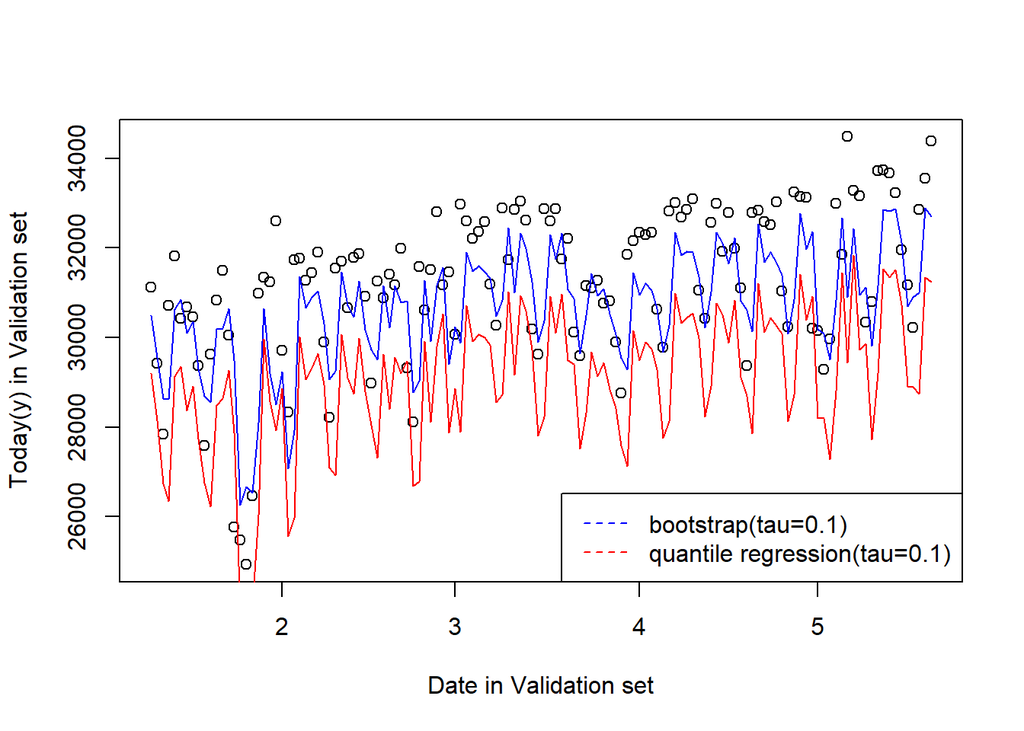

```r
plot(val[,1], val[,2], xlab = "Date in Validation set", ylab = "Today(y) in Validation set")
lines(val[,1],percent.val, col="blue")
lines(val$Date, pred.rq[,1] , col="red")
legend("bottomright", c( "bootstrap(tau=0.1)", "quantile regression(tau=0.1)") , col=c("blue","red"), lty=2)
```

**### (f)** 부트스트랩은 반복적인 적합을 통해 변동성을 지닌 모형의 계수에 대한 standard error를 구하고자 쓰는 기법이다. 이때 상사가 이야기하는 방법에 대해서 생각해 보았을때 오점을 전산실험의 결과 시각화한 그래프를 통해 알 수 있다. 직관적으로 생각해 보았을 때 먼저 부트스트랩 데이터 셋 1000개를 통해 적합한 회귀 직선과 yhat값들은 선형회귀를 통한 적합값으로 이들 각각은 E(Y|X=x)를 구한것이다. 이들을 나열하여 10% 값에 해당하는 데이터들은 각각의 X데이터(설명변수)에 대한 조건부 Y의 기댓값의 변동성에 대한 하위 10%를 구한것이다. 그러나 실질적으로 quantile(0.1)은 특정 X값에 대한 변수 Y의 전체 확률 분포에서 하위 10%를 이야기한다. 따라서 상사의 얘기에 반박할 수 있다.**

### 전산실험

```r
set.seed(1)
n =100
x.ex = rnorm(n)

beta.true = c(2,3)
x_beta = beta.true[1] + beta.true[2] * x.ex

y.ex = rnorm(n=n, mean=x_beta+1.3)

mat = data.frame(x.ex, y.ex)
mat.tr = mat[1:80,]
mat.val = mat[81:100,]

pred.ex = matrix(rep(NA,1000*20), nrow=20, ncol=1000)
ord.ex = t(pred.ex)

for (b in 1:1000) {
  set.seed(b*10)
  ind.tr.b = sample(1:80, size =80 , replace = T)
  tr.b = mat.tr[ind.tr.b,]
  fit.b = lm(y.ex~x.ex,data=tr.b)
  pred.ex[,b] = predict(fit.b, newdata=mat.val)
}

for (i in 1:nrow(pred.ex)) {
  ord.ex[,i] = sort(pred.ex[i,])
}

percent.ex= ord.ex[100,]

fit.r = rq(y.ex~x.ex, data= mat.tr, tau=0.1)
pred.r = predict(fit.r, newdata = mat.val)

ori.linear = lm(y.ex~x.ex, data= mat.tr)
ori.pred = predict(ori.linear,newdata = mat.val)
```

- 시각화

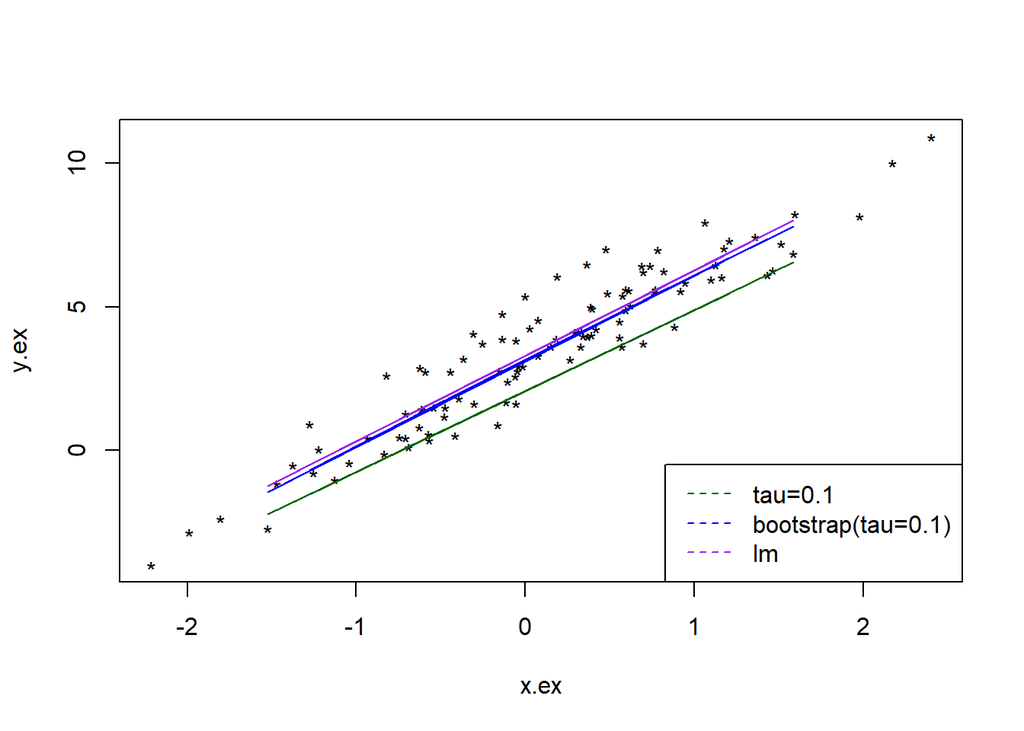

```r
plot(x.ex,y.ex,pch="*")
lines(mat.val$x.ex, pred.r, col="darkgreen")
lines(mat.val$x.ex, percent.ex, col="blue")
lines(mat.val$x.ex, ori.pred, col="purple")
legend("bottomright", c( "tau=0.1", "bootstrap(tau=0.1)", "lm") , col=c("darkgreen","blue","purple"), lty=2)
```

####부트스트랩핑하여 하위 10%를 이은 선과 원래 선형회귀 적합 직선과 비슷함을 볼 수 있다.